# PAVITHRA S _18BTRCR033 And AAKANKSHA D_18BTCR001

# AUTHENTICATING BANK CURRENCY NOTE

Support Vector Machines are supervised learning models that evaluate the data and recognize the patterns to classify the data. It creates a decision boundary to separate the two classes in the data. In SVM, each data item is plotted on the graph and then classification is performed to find the hyper plane that differentiates the two classes.

# Importing libraries

```python
import pandas as pd
import numpy as np
import matplotlib.pyplot as plt
%matplotlib inline
```

# Importing dataset(bill_authentication)

```python
bankdata = pd.read_csv("bill_authentication.csv")
bankdata
```

|  | Variance | Skewness | Curtosis | Entropy | Class |
| --- | --- | --- | --- | --- | --- |
| 0 | 3.62160 | 8.66610 | -2.8073 | -0.44699 | 0 |
| 1 | 4.54590 | 8.16740 | -2.4586 | -1.46210 | 0 |
| 2 | 3.86600 | -2.63830 | 1.9242 | 0.10645 | 0 |
| 3 | 3.45660 | 9.52280 | -4.0112 | -3.59440 | 0 |
| 4 | 0.32924 | -4.45520 | 4.5718 | -0.98880 | 0 |
| ... | ... | ... | ... | ... | ... |
| 1367 | 0.40614 | 1.34920 | -1.4501 | -0.55949 | 1 |
| 1368 | -1.38870 | -4.87730 | 6.4774 | 0.34179 | 1 |
| 1369 | -3.75030 | -13.45860 | 17.5932 | -2.77710 | 1 |
| 1370 | -3.56370 | -8.38270 | 12.3930 | -1.28230 | 1 |
| 1371 | -2.54190 | -0.65804 | 2.6842 | 1.19520 | 1 |

1372 rows × 5 columns

The task is to predict whether a bank currency note is authentic or not based upon four attributes of the note i.e. skewness of the wavelet transformed image, variance of the image, entropy of the image, and curtosis of the image. This is a binary classification problem and we will use SVM algorithm to solve this problem.

# Exploratory Data Analysis

```python
bankdata.head
```

```
<bound method NDFrame.head of       Variance  Skewness  Curtosis  Entropy  Class
0      3.62160   8.66610   -2.8073 -0.44699      0
1      4.54590   8.16740   -2.4586 -1.46210      0
2      3.86600  -2.63830    1.9242  0.10645      0
3      3.45660   9.52280   -4.0112 -3.59440      0
4      0.32924  -4.45520    4.5718 -0.98880      0
...        ...       ...       ...      ...    ...
1367   0.40614   1.34920   -1.4501 -0.55949      1
1368  -1.38870  -4.87730    6.4774  0.34179      1
1369  -3.75030 -13.45860   17.5932 -2.77710      1
1370  -3.56370  -8.38270   12.3930 -1.28230      1
1371  -2.54190  -0.65804    2.6842  1.19520      1

[1372 rows x 5 columns]>
```

```python
bankdata.isnull().sum()
```

```
Variance    0
Skewness    0
Curtosis    0
Entropy     0
Class       0
dtype: int64
```

```python
bankdata.shape
```

```
(1372, 5)
```

# Data Preprocessing

Data preprocessing involves (1) Dividing the data into attributes and labels. (2) dividing the data into training and testing sets.

Dividing data into attributes and labels

```python
X = bankdata.drop('Class', axis=1)
y = bankdata['Class']
```

In the first line of the script above, all the columns of the bankdata dataframe are being stored in the X variable except the "Class" column, which is the label column. The drop() method drops this column.

The final preprocessing step is to divide data into training and test sets. The model_selection library of the Scikit-Learn library contains the train_test_split method that allows divide data into training and test sets.

```python
from sklearn.model_selection import train_test_split
X_train, X_test, y_train, y_test = train_test_split(X, y, test_size = 0.20)
print ('Train set:', X_train.shape,  y_train.shape)
print ('Test set:', X_test.shape,  y_test.shape)
```

```
Train set: (1097, 4) (1097,)
Test set: (275, 4) (275,)
```

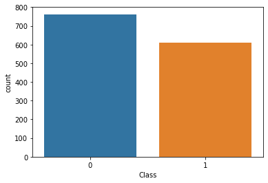

```python
import seaborn as sns
sns.countplot(bankdata['Class'])
```

```python
bankdata['Class'].value_counts()
```

```
0    762
1    610
Name: Class, dtype: int64
```

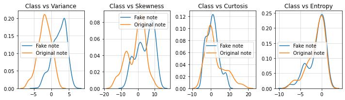

```python
col_names = bankdata.drop('Class', axis = 1).columns.tolist()

plt.figure(figsize = (10,3))
i = 0
for col in col_names:
    plt.subplot(1,4,i+1)
    plt.grid(True, alpha =0.5)
    sns.kdeplot(bankdata[col][bankdata['Class'] ==0], label = 'Fake note')
    sns.kdeplot(bankdata[col][bankdata['Class'] ==1], label = 'Original note')
    plt.title('Class vs ' + col)
    plt.tight_layout()
    i+=1
plt.show()
```

# Find correlation between each features

|  | Variance | Skewness | Curtosis | Entropy | Class |
| --- | --- | --- | --- | --- | --- |
| Variance | 1.000000 | 0.264026 | -0.380850 | 0.276817 | -0.724843 |
| Skewness | 0.264026 | 1.000000 | -0.786895 | -0.526321 | -0.444688 |
| Curtosis | -0.380850 | -0.786895 | 1.000000 | 0.318841 | 0.155883 |
| Entropy | 0.276817 | -0.526321 | 0.318841 | 1.000000 | -0.023424 |
| Class | -0.724843 | -0.444688 | 0.155883 | -0.023424 | 1.000000 |

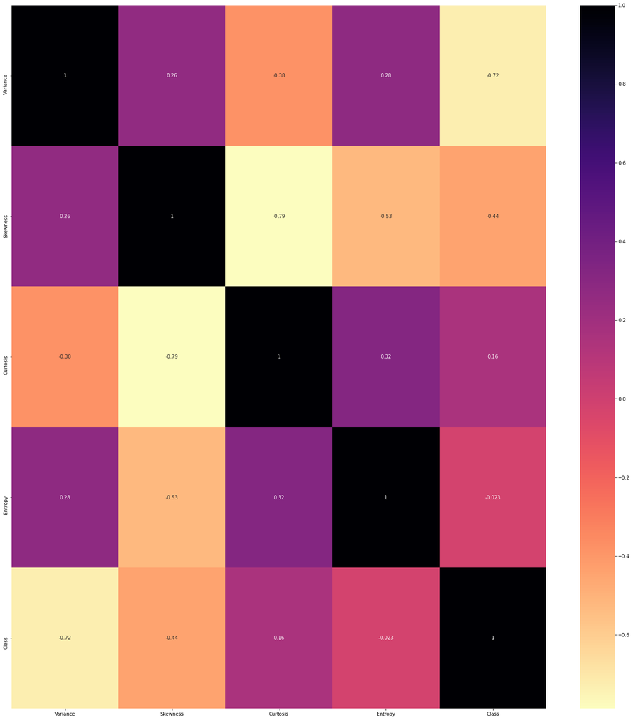

```python
plt.figure(figsize = (25,27))
sns.heatmap(bankdata.corr(),annot = True ,cmap = 'magma_r')
bankdata.corr(method ='pearson')
```

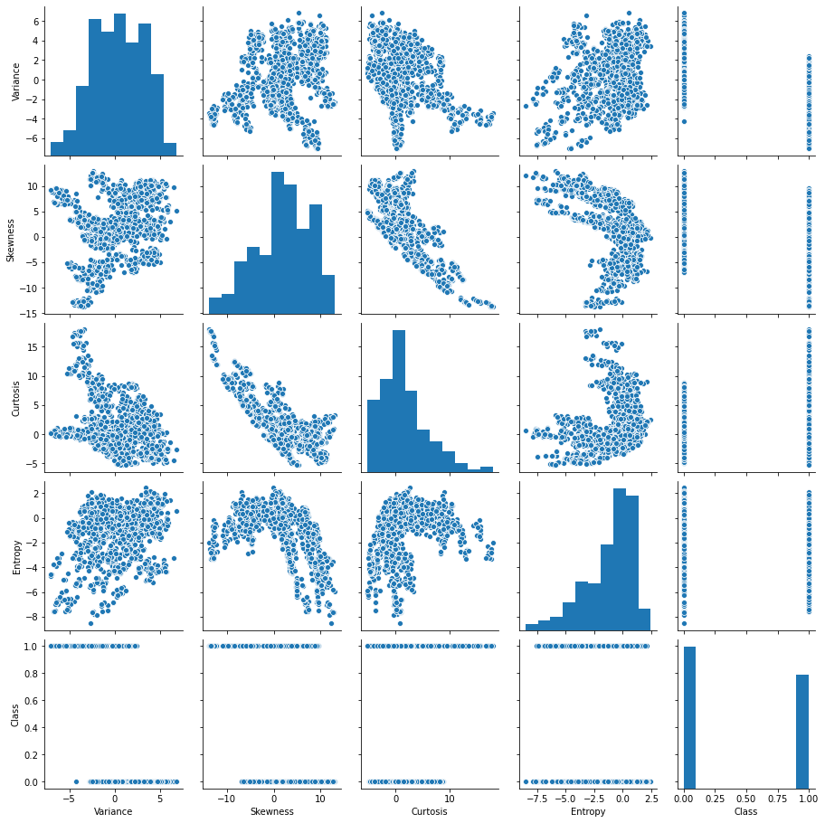

```python
sns.pairplot(bankdata)
```

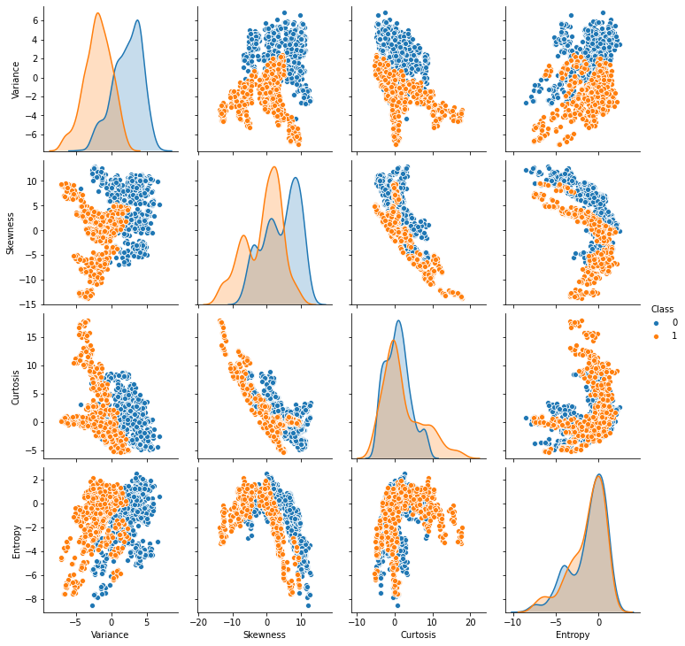

```python
sns.pairplot(bankdata, hue = 'Class', vars = ['Variance','Skewness','Curtosis','Entropy'])
```

# Training the Algorithm

Next is to train our SVM on the training data. Scikit-Learn contains the svm library, which contains built-in classes for different SVM algorithms. Since we are going to perform a classification task, we will use the support vector classifier class, which is written as SVC in the Scikit-Learn's svm library. This class takes one parameter.

```python
from sklearn.svm import SVC
s = SVC()
svclassifier = SVC(kernel='linear')
svclassifier.fit(X_train, y_train)
```

```
SVC(kernel='linear')
```

# Making Predictions

```python
y_pred = svclassifier.predict(X_test)
```

```python
from sklearn.metrics import accuracy_score
```

```python
accuracy_score(y_test,y_pred)
```

[output not shown]

# As the accuracy of our model is 99% which is very good in prediction

# Evaluating the Algorithm

```python
from sklearn.metrics import confusion_matrix,classification_report
print(confusion_matrix(y_test,y_pred))
cm = confusion_matrix(y_test, y_pred)
```

```
[[155   2]
 [  0 118]]
```

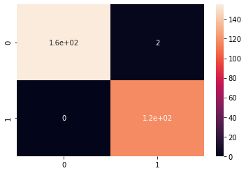

```python
sns.heatmap(cm , annot = True)
```

```python
print(classification_report(y_test,y_pred))
```

```
              precision    recall  f1-score   support

           0       1.00      0.99      0.99       157
           1       0.98      1.00      0.99       118

    accuracy                           0.99       275
   macro avg       0.99      0.99      0.99       275
weighted avg       0.99      0.99      0.99       275
```

SVM uses a kernel function that projects the data from a lower-dimensional space to a higher-dimensional space. This is done to make the non-linearly separable data into linearly separable.

# Different types of Kernels

# 1.RBF

Gaussian RBF(Radial Basis Function) is another popular Kernel method used in SVM models for more. RBF kernel is a function whose value depends on the distance from the origin or from some point.

```python
from sklearn.svm import SVC
svclassifier = SVC(kernel='rbf')
svclassifier.fit(X_train, y_train)
```

```
SVC()
```

Prediction and Evaluation

```python
y_pred = svclassifier.predict(X_test)
```

```python
from sklearn.metrics import classification_report, confusion_matrix
print(confusion_matrix(y_test, y_pred))
print(classification_report(y_test, y_pred))
```

```
[[157   0]
 [  0 118]]
              precision    recall  f1-score   support

           0       1.00      1.00      1.00       157
           1       1.00      1.00      1.00       118

    accuracy                           1.00       275
   macro avg       1.00      1.00      1.00       275
weighted avg       1.00      1.00      1.00       275
```

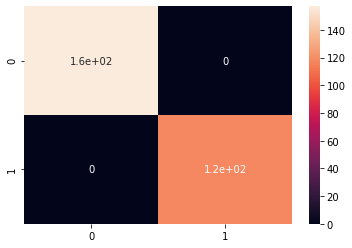

```python
cm = confusion_matrix(y_test, y_pred)
sns.heatmap(cm , annot = True)
```

```python
cr = classification_report(y_test, y_pred,output_dict=True)

df = pd.DataFrame(cr).transpose()
df
```

|  | precision | recall | f1-score | support |
| --- | --- | --- | --- | --- |
| 0 | 1.0 | 1.0 | 1.0 | 157.0 |
| 1 | 1.0 | 1.0 | 1.0 | 118.0 |
| accuracy | 1.0 | 1.0 | 1.0 | 1.0 |
| macro avg | 1.0 | 1.0 | 1.0 | 275.0 |
| weighted avg | 1.0 | 1.0 | 1.0 | 275.0 |

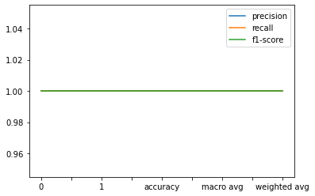

```python
df1 = df.drop(['support'],axis=True)
df1.plot()
```

# 2. Linear kernal

Linear Kernel is used when the data is Linearly separable, that is, it can be separated using a single Line. It is one of the most common kernels to be used.

```python
from sklearn.svm import SVC
svclassifier = SVC(kernel='linear')
svclassifier.fit(X_train, y_train)
```

```
SVC(kernel='linear')
```

```python
y_pred = svclassifier.predict(X_test)
```

```python
from sklearn.metrics import classification_report, confusion_matrix
print(confusion_matrix(y_test,y_pred))
print(classification_report(y_test,y_pred))
```

```
[[155   2]
 [  0 118]]
              precision    recall  f1-score   support

           0       1.00      0.99      0.99       157
           1       0.98      1.00      0.99       118

    accuracy                           0.99       275
   macro avg       0.99      0.99      0.99       275
weighted avg       0.99      0.99      0.99       275
```

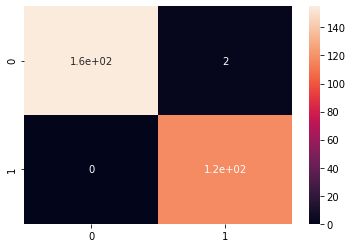

```python
cm = confusion_matrix(y_test, y_pred)
sns.heatmap(cm , annot = True)
```

```python
cr = classification_report(y_test, y_pred,output_dict=True)

df = pd.DataFrame(cr).transpose()
df
```

|  | precision | recall | f1-score | support |
| --- | --- | --- | --- | --- |
| 0 | 1.000000 | 0.987261 | 0.993590 | 157.000000 |
| 1 | 0.983333 | 1.000000 | 0.991597 | 118.000000 |
| accuracy | 0.992727 | 0.992727 | 0.992727 | 0.992727 |
| macro avg | 0.991667 | 0.993631 | 0.992593 | 275.000000 |
| weighted avg | 0.992848 | 0.992727 | 0.992735 | 275.000000 |

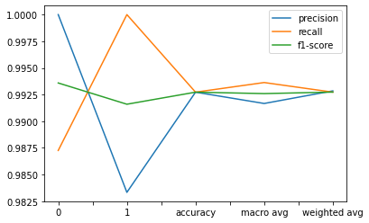

```python
df1 = df.drop(['support'],axis=True)
df1.plot()
```

```python
from sklearn.metrics import accuracy_score
accuracy_score(y_test,y_pred)
```

[output not shown]

# 3.Polynomial Kernel

It represents the similarity of vectors (training samples) in a feature space over polynomials of the original variables, allowing learning of non-linear models.

```python
from sklearn.svm import SVC
svclassifier = SVC(kernel='poly', degree=8)
svclassifier.fit(X_train, y_train)
```

```
SVC(degree=8, kernel='poly')
```

```python
y_pred = svclassifier.predict(X_test)
```

```python
from sklearn.metrics import classification_report, confusion_matrix
print(confusion_matrix(y_test, y_pred))
print(classification_report(y_test, y_pred))
```

```
[[ 89  68]
 [  0 118]]
              precision    recall  f1-score   support

           0       1.00      0.57      0.72       157
           1       0.63      1.00      0.78       118

    accuracy                           0.75       275
   macro avg       0.82      0.78      0.75       275
weighted avg       0.84      0.75      0.75       275
```

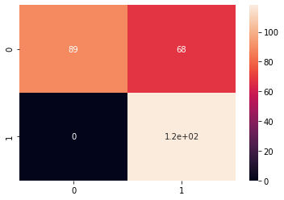

```python
cm = confusion_matrix(y_test, y_pred)
sns.heatmap(cm , annot = True)
```

```python
cr = classification_report(y_test, y_pred,output_dict=True)

df = pd.DataFrame(cr).transpose()
df
```

|  | precision | recall | f1-score | support |
| --- | --- | --- | --- | --- |
| 0 | 1.000000 | 0.566879 | 0.723577 | 157.000000 |
| 1 | 0.634409 | 1.000000 | 0.776316 | 118.000000 |
| accuracy | 0.752727 | 0.752727 | 0.752727 | 0.752727 |
| macro avg | 0.817204 | 0.783439 | 0.749947 | 275.000000 |
| weighted avg | 0.843128 | 0.752727 | 0.746207 | 275.000000 |

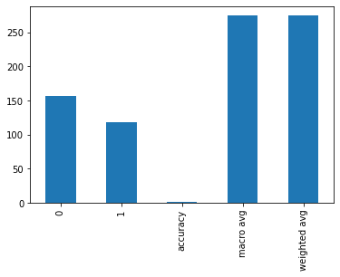

```python
df2 = df['support']

df2.plot.bar()
```

# 4. Sigmoid Kernel

```python
from sklearn.svm import SVC
svclassifier = SVC(kernel='sigmoid')
svclassifier.fit(X_train, y_train)
```

```
SVC(kernel='sigmoid')
```

```python
y_pred = svclassifier.predict(X_test)
```

```python
from sklearn.metrics import classification_report, confusion_matrix
print(confusion_matrix(y_test, y_pred))
print(classification_report(y_test, y_pred))
```

```
[[116  41]
 [ 49  69]]
              precision    recall  f1-score   support

           0       0.70      0.74      0.72       157
           1       0.63      0.58      0.61       118

    accuracy                           0.67       275
   macro avg       0.67      0.66      0.66       275
weighted avg       0.67      0.67      0.67       275
```

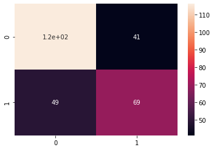

```python
cm = confusion_matrix(y_test, y_pred)
sns.heatmap(cm , annot = True)
```

```python
cr = classification_report(y_test, y_pred,output_dict=True)

df = pd.DataFrame(cr).transpose()
df
```

|  | precision | recall | f1-score | support |
| --- | --- | --- | --- | --- |
| 0 | 0.703030 | 0.738854 | 0.720497 | 157.000000 |
| 1 | 0.627273 | 0.584746 | 0.605263 | 118.000000 |
| accuracy | 0.672727 | 0.672727 | 0.672727 | 0.672727 |
| macro avg | 0.665152 | 0.661800 | 0.662880 | 275.000000 |
| weighted avg | 0.670523 | 0.672727 | 0.671051 | 275.000000 |

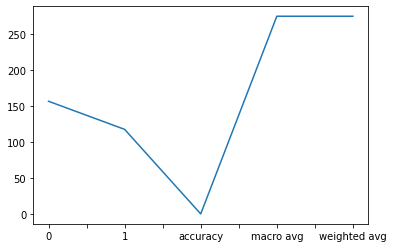

```python
df2 = df['support']
df2.plot()
```

# 5. Gaussian Kernel

```python
from sklearn.svm import SVC
svclassifier = SVC(kernel='rbf')
svclassifier.fit(X_train, y_train)
```

```
SVC()
```

```python
y_pred = svclassifier.predict(X_test)
```

```python
from sklearn.metrics import classification_report, confusion_matrix
print(confusion_matrix(y_test, y_pred))
print(classification_report(y_test, y_pred))
```

```
[[157   0]
 [  0 118]]
              precision    recall  f1-score   support

           0       1.00      1.00      1.00       157
           1       1.00      1.00      1.00       118

    accuracy                           1.00       275
   macro avg       1.00      1.00      1.00       275
weighted avg       1.00      1.00      1.00       275
```

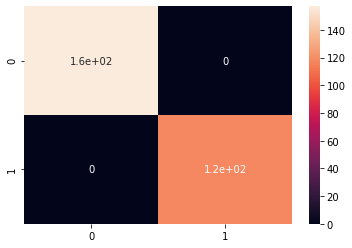

```python
cm = confusion_matrix(y_test, y_pred)
sns.heatmap(cm , annot = True)
```

```python
cr = classification_report(y_test, y_pred,output_dict=True)

df = pd.DataFrame(cr).transpose()
df
```

|  | precision | recall | f1-score | support |
| --- | --- | --- | --- | --- |
| 0 | 1.0 | 1.0 | 1.0 | 157.0 |
| 1 | 1.0 | 1.0 | 1.0 | 118.0 |
| accuracy | 1.0 | 1.0 | 1.0 | 1.0 |
| macro avg | 1.0 | 1.0 | 1.0 | 275.0 |
| weighted avg | 1.0 | 1.0 | 1.0 | 275.0 |

[figure not shown]

```python
df1.plot.bar()
```

# Conclusion:

since our RBF and GUASSIAN gives the best model by predicting the accuaracy when compared to others and Sigmoid is the worst model as it predicts least accuracy.